# R Notebook

# Libraries

```r
library(tidyverse)
library(janitor)
library(here)
```

# Data

```r
community_belonging <- clean_names(read_csv(here("raw_data/community_belonging.csv")))
green_spaces <- clean_names(read_csv(here("raw_data/green_spaces.csv")))
neighbourhood_rating <- clean_names(read_csv(here("raw_data/neighbourhood_rating.csv")))
```

```r
community_belonging
```

| feature_code | date_code | measurement | units | value | community_belonging | gender | urban_rural_classification | simd_quintiles | type_of_tenure | household_type | ethnicity | walking_distance_to_nearest_greenspace |
| --- | --- | --- | --- | --- | --- | --- | --- | --- | --- | --- | --- | --- |
| S12000040 | 2018 | 95% Upper Confidence Limit, Percent | Percent Of Adults | 66.6 | Very strongly | All | All | All | All | All | All | More than 10 minutes |
| S12000029 | 2018 | 95% Lower Confidence Limit, Percent | Percent Of Adults | 29.3 | Very strongly | All | All | All | All | All | All | More than 10 minutes |
| S12000040 | 2018 | 95% Lower Confidence Limit, Percent | Percent Of Adults | 40.2 | Very strongly | All | All | All | All | All | All | More than 10 minutes |
| S12000049 | 2014 | 95% Upper Confidence Limit, Percent | Percent Of Adults | 50.9 | Fairly strongly | All | All | All | All | All | All | More than 10 minutes |
| S12000049 | 2014 | 95% Lower Confidence Limit, Percent | Percent Of Adults | 33.6 | Fairly strongly | All | All | All | All | All | All | More than 10 minutes |
| S92000003 | 2017 | Percent | Percent Of Adults | 42.0 | Fairly strongly | All | All | All | All | All | All | More than 10 minutes |
| S12000040 | 2017 | Percent | Percent Of Adults | 43.0 | Fairly strongly | All | All | All | All | All | All | More than 10 minutes |
| S12000040 | 2017 | 95% Lower Confidence Limit, Percent | Percent Of Adults | 29.3 | Fairly strongly | All | All | All | All | All | All | More than 10 minutes |
| S92000003 | 2017 | 95% Lower Confidence Limit, Percent | Percent Of Adults | 39.1 | Fairly strongly | All | All | All | All | All | All | More than 10 minutes |
| S12000049 | 2014 | Percent | Percent Of Adults | 42.0 | Fairly strongly | All | All | All | All | All | All | More than 10 minutes |

[output cut: 990 more lines]

```r
green_spaces
```

| feature_code | date_code | measurement | units | value | distance_to_nearest_green_or_blue_space | age | gender | urban_rural_classification | simd_quintiles | type_of_tenure | household_type | ethnicity |
| --- | --- | --- | --- | --- | --- | --- | --- | --- | --- | --- | --- | --- |
| S12000026 | 2013 | 95% Lower Confidence Limit, Percent | Percent Of Adults | 71.0 | A 5 minute walk or less | All | All | All | All | All | All | All |
| S12000045 | 2017 | Percent | Percent Of Adults | 59.0 | A 5 minute walk or less | All | All | All | All | All | Pensioners | All |
| S12000026 | 2014 | 95% Upper Confidence Limit, Percent | Percent Of Adults | 86.9 | A 5 minute walk or less | All | All | All | All | All | All | All |
| S12000026 | 2017 | 95% Upper Confidence Limit, Percent | Percent Of Adults | 80.9 | A 5 minute walk or less | All | All | All | All | All | All | All |
| S12000026 | 2017 | 95% Upper Confidence Limit, Percent | Percent Of Adults | 79.6 | A 5 minute walk or less | All | All | All | All | All | Pensioners | All |
| S12000026 | 2014 | 95% Lower Confidence Limit, Percent | Percent Of Adults | 76.8 | A 5 minute walk or less | All | All | All | All | All | All | All |
| S12000026 | 2013 | 95% Upper Confidence Limit, Percent | Percent Of Adults | 80.7 | A 5 minute walk or less | All | All | All | All | All | Pensioners | All |
| S12000026 | 2014 | Percent | Percent Of Adults | 77.0 | A 5 minute walk or less | All | Female | All | All | All | All | All |
| S12000033 | 2017 | 95% Lower Confidence Limit, Percent | Percent Of Adults | 53.0 | A 5 minute walk or less | All | Male | All | All | All | All | All |
| S12000026 | 2014 | 95% Lower Confidence Limit, Percent | Percent Of Adults | 80.0 | A 5 minute walk or less | All | Male | All | All | All | All | All |

[output cut: 990 more lines]

```r
neighbourhood_rating
```

| feature_code | date_code | measurement | units | value | neighbourhood_rating | gender | urban_rural_classification | simd_quintiles | type_of_tenure | household_type | ethnicity | walking_distance_to_nearest_greenspace |
| --- | --- | --- | --- | --- | --- | --- | --- | --- | --- | --- | --- | --- |
| S12000033 | 2018 | 95% Lower Confidence Limit, Percent | Percent Of Adults | 34.2 | Very good | All | All | All | All | All | All | More than 10 minutes |
| S12000039 | 2016 | 95% Lower Confidence Limit, Percent | Percent Of Adults | 35.1 | Very good | All | All | All | All | All | All | More than 10 minutes |
| S12000039 | 2016 | 95% Upper Confidence Limit, Percent | Percent Of Adults | 63.3 | Very good | All | All | All | All | All | All | More than 10 minutes |
| S12000049 | 2013 | 95% Lower Confidence Limit, Percent | Percent Of Adults | 1.5 | Very poor | All | All | All | All | All | All | More than 10 minutes |
| S12000036 | 2018 | 95% Upper Confidence Limit, Percent | Percent Of Adults | 11.9 | Fairly poor | All | All | All | All | All | All | More than 10 minutes |
| S12000049 | 2014 | 95% Upper Confidence Limit, Percent | Percent Of Adults | 5.7 | Very poor | All | All | All | All | All | All | More than 10 minutes |
| S12000034 | 2019 | Percent | Percent Of Adults | 73.0 | Very good | All | All | All | All | All | All | More than 10 minutes |
| S12000023 | 2019 | Percent | Percent Of Adults | 71.0 | Very good | All | All | All | All | All | All | More than 10 minutes |
| S12000050 | 2019 | Percent | Percent Of Adults | 42.0 | Very good | All | All | All | All | All | All | More than 10 minutes |
| S92000003 | 2013 | 95% Lower Confidence Limit, Percent | Percent Of Adults | 38.1 | Fairly good | All | All | All | All | All | All | More than 10 minutes |

[output cut: 990 more lines]

# Explore Community Belonging

```r
community_belonging %>%
   summarise(across(.cols = everything(), .fns = ~sum(is.na(.x))))
```

| feature_code | date_code | measurement | units | value | community_belonging | gender | urban_rural_classification | simd_quintiles | type_of_tenure | household_type | ethnicity | walking_distance_to_nearest_greenspace |
| --- | --- | --- | --- | --- | --- | --- | --- | --- | --- | --- | --- | --- |
| 0 | 0 | 0 | 0 | 0 | 0 | 0 | 0 | 0 | 0 | 0 | 0 | 0 |

There are no NA values

```r
community_belonging %>%
  distinct(units)
```

| units |
| --- |
| Percent Of Adults |

There is only 1 value in this column. It can be removed in the cleaning script

```r
community_belonging %>%
  distinct() %>%
  nrow()
```

```
[1] 43611
```

```r
community_belonging %>%
  nrow()
```

```
[1] 43611
```

No duplicates

```r
community_belonging %>%
  filter(feature_code == "S12000036", year == "2016",
         walking_distance_to_nearest_greenspace == "More than 10 minutes")
```

[output not shown]

There appear to be some missing values such as how many people voted “Don’t know” to community belonging where the walking distance is greater than 10 minutes. Is it sensible to assume this is 0?

```r
community_belonging %>%
  filter(feature_code == "S12000036", year == "2016",
         walking_distance_to_nearest_greenspace == "More than 10 minutes",
         measurement == "Percent") %>%
  summarise(sum(value))
```

Yes, the others add up to 100% so 0% voted “Don’t know”.

## What is the granularity of the data?

```r
community_belonging %>%
  filter(date_code == 2019,
         gender == "Female")
```

The feature codes look like council areas. The name of the area if going to be more useful than codes.

[figure not shown]

```r
council_areas <- clean_names(read_csv(here("raw_data/council_area_codes.csv")))
council_areas_clean <- council_areas %>%
  select(ca, ca_name) %>%
  add_row(ca = "S92000003" ,ca_name = "Scotland")
```

Some rows appear to be for the whole of Scotland so I have added a row for this code.

```r
community_belonging <- community_belonging %>%
  left_join(council_areas_clean, by = c("feature_code" = "ca"))
```

When plotting the order of community belonging will not make sense, therefore this should be factored.

```r
community_belonging <- community_belonging %>%
  mutate(community_belonging = factor(community_belonging,
                                      levels = c("Not at all strongly",
                                                 "Not very strongly",
                                                 "Don't know",
                                                 "Fairly strongly",
                                                 "Very strongly")))
```

> Each row appears to be a demographic (eg. Female, more than 10 minutes to nearest greenspace, etc), category of community belonging, measurement, and the percentage of people of that demographic that scored their community belonging at that category.

```r
community_belonging %>%
  distinct(walking_distance_to_nearest_greenspace)
```

## Data

- feature_code = council area or all of scotland
- date_code = year between 2013 and 2019
- measurement = whether the value is a percent, or confidence limit
- value = percent of people that gave that rating or upper and lower confidence levels for that percentage
- **community_belonging** = rating of community belonging
- gender = Male/Female
- urban_rural_classification = Urban/Rural
- simd_quintiles = 80% least deprived/20% most deprived
- type_of_tenure = Owned Mortgage/Loan / Owned Outright / Social Rented / Private Rented / Other
- household_type = With Children / Pensioners / Adults
- ethnicity = White / Other
- **walking_distance_to_nearest_greenspace** = More than 10 minutes / Less than 10 minutes / Don’t know

### Quality of data

```r
community_belonging %>%
  group_by(walking_distance_to_nearest_greenspace) %>%
  summarise(total = n())
```

```r
(105/(4107+1035))*100
```

Walking distance to nearest greenspace is likely self reported, only 2% of people do not know the answer and there is a reasonable amount of data that do know.

## Experimental plotting

[figure not shown]

Does this add up to 100%?

```r
community_belonging %>%
  filter(date_code == 2019,
         gender == "Female",
         ca_name == "West Lothian") %>%
  select(measurement:community_belonging) %>%
  pivot_wider(names_from = measurement, values_from = value) %>%
  clean_names() %>%
  summarise(sum(percent))
```

Yes.

## Community belonging and green space

```r
community_belonging %>%
  filter(walking_distance_to_nearest_greenspace != "All",
         ca_name == "Scotland",
         date_code == 2019) %>%
  pivot_wider(names_from = measurement, values_from = value) %>%
  clean_names() %>%
  ggplot(aes(community_belonging, percent, fill = walking_distance_to_nearest_greenspace)) +
  geom_col(position = "dodge") +
  facet_wrap(~walking_distance_to_nearest_greenspace)
```

```r
community_belonging %>%
  filter(walking_distance_to_nearest_greenspace != "All",
         ca_name == "Scotland",
         date_code == 2019) %>%
  pivot_wider(names_from = measurement, values_from = value) %>%
  clean_names() %>%
  group_by(walking_distance_to_nearest_greenspace) %>%
  summarise(total = sum(percent))
```

It is difficult to quanity the difference.  
Perhaps we could use a score for community belonging? (0-5 or (-2)-(+2))

```r
community_belonging %>%
  distinct(community_belonging)
```

```r
community_belonging_scored <- community_belonging %>%
  mutate(belonging_score = case_when(
    community_belonging == "Not at all strongly" ~ 1,
    community_belonging == "Not very strongly" ~ 2,
    community_belonging == "Don't know" ~ 3,
    community_belonging == "Fairly strongly" ~ 4,
    community_belonging == "Very strongly" ~ 5,
  ),
  belonging_score_zeroed = case_when(
    community_belonging == "Not at all strongly" ~ -2,
    community_belonging == "Not very strongly" ~ -1,
    community_belonging == "Don't know" ~ 0,
    community_belonging == "Fairly strongly" ~ 1,
    community_belonging == "Very strongly" ~ 2,
  ))
```

```r
community_belonging_scored %>%
  filter(walking_distance_to_nearest_greenspace != "All",
         ca_name == "Scotland",
         date_code == 2019) %>%
  pivot_wider(names_from = measurement, values_from = value) %>%
  clean_names() %>%
  mutate(score = percent * belonging_score,
         score_zero = percent * belonging_score_zeroed) %>%
  group_by(walking_distance_to_nearest_greenspace) %>%
  summarise(overall_belonging = mean(score),
            overall_belonging_zero = mean(score_zero)) %>%
  ggplot(aes(walking_distance_to_nearest_greenspace, overall_belonging_zero)) +
  geom_col()
```

With normal scoring the maximum possible is 100% scoring 5 -> 500 (0:500)  
With zeroed score the maximum possible is 100% scoring 2 -> 200 (-200:200)  
This might be better on a scale of -1 to 1.

```r
community_belonging_scored %>%
  filter(walking_distance_to_nearest_greenspace != "All",
         ca_name == "Scotland",
         date_code == 2019) %>%
  pivot_wider(names_from = measurement, values_from = value) %>%
  clean_names() %>%
  mutate(score_zero = (percent * belonging_score_zeroed)/200) %>%
  group_by(walking_distance_to_nearest_greenspace) %>%
  summarise(overall_belonging_zero = mean(score_zero)) %>%
  ggplot(aes(walking_distance_to_nearest_greenspace, overall_belonging_zero)) +
  geom_col()
```

```r
community_belonging_scored %>%
  filter(walking_distance_to_nearest_greenspace != "All",
         ca_name == "Scotland",
         date_code == 2019) %>%
  pivot_wider(names_from = measurement, values_from = value) %>%
  clean_names() %>%
  mutate(score_zero = (percent * belonging_score_zeroed)/200) %>%
  ggplot(aes(walking_distance_to_nearest_greenspace, score_zero)) +
  geom_point()
```

App should explore community belonging for each group.

# Green spaces

```r
green_spaces
green_spaces %>%
  distinct(age)
```

- feature_code = council area or all of scotland
- date_code = year between 2013 and 2019
- measurement = whether the value is a percent, or confidence limit
- value = percent of people that gave that rating or upper and lower confidence levels for that percentage
- **distance_to_nearest_green_or_blue_space** = 5 minute walk or less / 6-10 minute walk / 11+ minute walk / Don’t know
- age = 16-34 / 35-64 / 65+
- gender = Male/Female
- urban_rural_classification = Urban/Rural
- simd_quintiles = 80% least deprived/20% most deprived
- type_of_tenure = Owned Mortgage/Loan / Owned Outright / Social Rented / Private Rented / Other
- household_type = With Children / Pensioners / Adults
- ethnicity = White / Other

This dataset tells us who has access to green or blue spaces within 10 minutes.

```r
green_spaces %>%
  left_join(council_areas_clean, by = c("feature_code" = "ca")) %>%
  filter(ca_name == "Scotland",
         urban_rural_classification == "Urban",
         measurement == "Percent") %>%
  ggplot(aes(date_code, value, colour = distance_to_nearest_green_or_blue_space)) +
  geom_line()
```

# Neighbourhood Rating

```r
neighbourhood_rating
```

```r
neighbourhood_rating %>%
  distinct() %>%
  nrow()

neighbourhood_rating %>%
  nrow()
```

```r
neighbourhood_rating %>%
  distinct(neighbourhood_rating)
```

# Tab data

```r
full_data_2019 <- read.delim(here("raw_data/tab/shs2019_social_public.tab"))
```

## Cleaning

```r
data_small <- full_data_2019 %>%
  filter(rand_ok == 1) %>%
  select(council, # council area
         randage, # age
         randgender, # gender
         RANDETH2012, # ethnicity
         #randecon,
         tenure_harm, #tenure_type
         hhtype_new, # household type (1, 2, 6, 7 = adult, 3, 4, 5 = children, 8 = pensioner)
         greenfar13, # how far to nearest green or blue space
         MD20QUIN, # SIMD (1 = most, 5 = least)
         SHS_2CLA, # urban_rural
         rb1, # neighbourhood rating
         commbel # community belonging
  )
data_small
```

| council | randage | randgender | RANDETH2012 | tenure_harm | hhtype_new | greenfar13 | MD20QUIN | SHS_2CLA | rb1 | commbel |
| --- | --- | --- | --- | --- | --- | --- | --- | --- | --- | --- |
| A | 48 | 1 | 1 | 1 | 1 | 1 | 5 | 1 | 1 | 2 |
| A | 67 | 1 | 1 | 2 | 7 | 1 | 5 | 1 | 1 | 1 |
| A | 75 | 2 | 1 | 2 | 8 | 2 | 5 | 1 | 1 | 1 |
| A | 63 | 1 | 1 | 2 | 1 | 1 | 5 | 1 | 1 | 1 |
| A | 72 | 2 | 1 | 2 | 7 | 2 | 4 | 1 | 1 | 2 |
| A | 72 | 2 | 1 | 4 | 8 | 1 | 4 | 1 | 1 | 1 |
| A | 55 | 2 | 1 | 2 | 7 | 1 | 5 | 1 | 1 | 2 |
| A | 26 | 1 | 1 | 2 | 6 | 1 | 5 | 1 | 2 | 2 |
| A | 16 | 2 | 1 | 2 | 5 | 5 | 5 | 1 | 1 | 2 |
| A | 34 | 1 | 1 | 1 | 2 | 1 | 5 | 1 | 2 | 3 |

[output cut: 990 more lines]

```r
data_clean <- data_small %>%
  rename("ethnicity" = "RANDETH2012") %>%
  rename("simd" = "MD20QUIN") %>%
  rename("urban_rural" = "SHS_2CLA") %>%
  mutate(
    household_type = factor(case_when(
      hhtype_new %in% c(1, 2, 6, 7) ~ "Adult",
      hhtype_new %in% c(3, 4, 5) ~ "Children",
      hhtype_new == 8 ~ "Pensioner"
    )),
    gender = factor(case_when(
      randgender == 1 ~ "Male",
      randgender == 2 ~ "Female",
      .default = "Other/Refused"
    )),
    ethnicity = factor(case_when(
      ethnicity == 1 ~ "White",
      ethnicity == 2 ~ "Other",
      .default = "Refused/Unknown"
    )),
    tenure = factor(case_when(
      tenure_harm == 1 ~ "Owned Outright",
      tenure_harm == 2 ~ "Owned Loan/Mortgage",
      tenure_harm == 3 | tenure_harm == 4  ~ "Social Rented",
      tenure_harm == 5 ~ "Private Rented",
      tenure_harm == 6 ~ "Other",
      .default = "Refused/Unknown"
    )),
    greenspace = factor(case_when(
      greenfar13 == 1 ~ "5 mins or less",
      greenfar13 == 2 ~ "6-10 mins",
      greenfar13 == 3 ~ "11-20 mins",
      greenfar13 == 4 ~ "21-30 mins",
      greenfar13 == 5 ~ "More than 30",
      greenfar13 == 6 ~ "Don't know"
    )),
    urban_rural = factor(case_when(
      urban_rural == 1 ~ "Urban",
      urban_rural == 2 ~ "Rural"
    )),
    neighbourhood_rating = factor(case_when(
      rb1 == 1 ~ "Very good",
      rb1 == 2 ~ "Fairly good",
      rb1 == 3 ~ "Fairly poor",
      rb1 == 4 ~ "Very poor",
      rb1 == 5 ~ "No opinion"
    )),
    community_belonging = factor(case_when(
      commbel == 1 ~ "Very strongly",
      commbel == 2 ~ "Fairly strongly",
      commbel == 3 ~ "Not very strongly",
      commbel == 4 ~ "Not at all strongly",
      commbel == 5 ~ "Don't know"
    )),
    council = factor(council)
    ) %>%
  select(-c(hhtype_new, randgender, tenure_harm, greenfar13, rb1, commbel)) %>%
  as_tibble()
```

```r
data_clean %>%
  summarise(across(.cols = everything(), .fns = ~sum(is.na(.x))))
```

| council | randage | ethnicity | simd | urban_rural | household_type | gender | tenure | greenspace | neighbourhood_rating | community_belonging |
| --- | --- | --- | --- | --- | --- | --- | --- | --- | --- | --- |
| 0 | 0 | 0 | 0 | 0 | 0 | 0 | 0 | 0 | 0 | 0 |

```r
data_clean
```

| council | randage | ethnicity | simd | urban_rural | household_type | gender | tenure | greenspace | neighbourhood_rating | community_belonging |
| --- | --- | --- | --- | --- | --- | --- | --- | --- | --- | --- |
| A | 48 | White | 5 | Urban | Adult | Male | Owned Outright | 5 mins or less | Very good | Fairly strongly |
| A | 67 | White | 5 | Urban | Adult | Male | Owned Loan/Mortgage | 5 mins or less | Very good | Very strongly |
| A | 75 | White | 5 | Urban | Pensioner | Female | Owned Loan/Mortgage | 6-10 mins | Very good | Very strongly |
| A | 63 | White | 5 | Urban | Adult | Male | Owned Loan/Mortgage | 5 mins or less | Very good | Very strongly |
| A | 72 | White | 4 | Urban | Adult | Female | Owned Loan/Mortgage | 6-10 mins | Very good | Fairly strongly |
| A | 72 | White | 4 | Urban | Pensioner | Female | Social Rented | 5 mins or less | Very good | Very strongly |
| A | 55 | White | 5 | Urban | Adult | Female | Owned Loan/Mortgage | 5 mins or less | Very good | Fairly strongly |
| A | 26 | White | 5 | Urban | Adult | Male | Owned Loan/Mortgage | 5 mins or less | Fairly good | Fairly strongly |
| A | 16 | White | 5 | Urban | Children | Female | Owned Loan/Mortgage | More than 30 | Very good | Fairly strongly |
| A | 34 | White | 5 | Urban | Adult | Male | Owned Outright | 5 mins or less | Fairly good | Not very strongly |

[output cut: 990 more lines]

```r
data_clean_1 <- data_clean %>%
  select(1:5, neighbourhood_rating)

data_clean_2 <- data_clean %>%
  select(6:11)
```

## Modelling

```r
library(rpart)
library(rpart.plot)
```

```r
n_data <- nrow(data_clean)

# create a test sample index
test_index <- sample(1:n_data, size = n_data * 0.2)

# create test set
thrones_test  <- slice(data_clean, test_index)

# create training set
thrones_train <- slice(data_clean, -test_index)
```

```r
neighbourhood_fit <- rpart(
  formula = neighbourhood_rating ~ .,
  data = data_clean_1,
  method = 'class'
)
```

## Stats

```r
data_clean <- read_csv(here("clean_data/full_2019_responses.csv")) %>%
  mutate(greenspace = factor(greenspace, levels = c("Don't know",
                  "5 mins or less",
                  "6-10 mins",
                  "11-20 mins",
                  "21-30 mins",
                  "More than 30")))
```

```r
plot_demographic_dist <- function(category){
  data_clean %>%
  filter(council %in% c("Eilean Siar", "Orkney", "Shetland", "East Renfrewshire",
                        "Highland", "Dundee City", "Aberdeen City", "Glasgow City",
                        "West Dunbartonshire", "Clackmannanshire")) %>%
  mutate(top_bottom = case_when(
    council %in% c("Eilean Siar", "Orkney", "Shetland",
                   "East Renfrewshire", "Highland") ~ "Top",
    .default = "Bottom"
  )) %>%
  group_by(council, top_bottom, {{category}}) %>%
  summarise(total = n()) %>%
  mutate(prop = (prop.table(total))*100) %>%
  ggplot(aes({{category}}, prop, fill = council)) +
  geom_col(position = "dodge") +
  facet_wrap(~top_bottom) +
  theme(axis.text.x = element_text(angle = 45, hjust = 1))
}
```

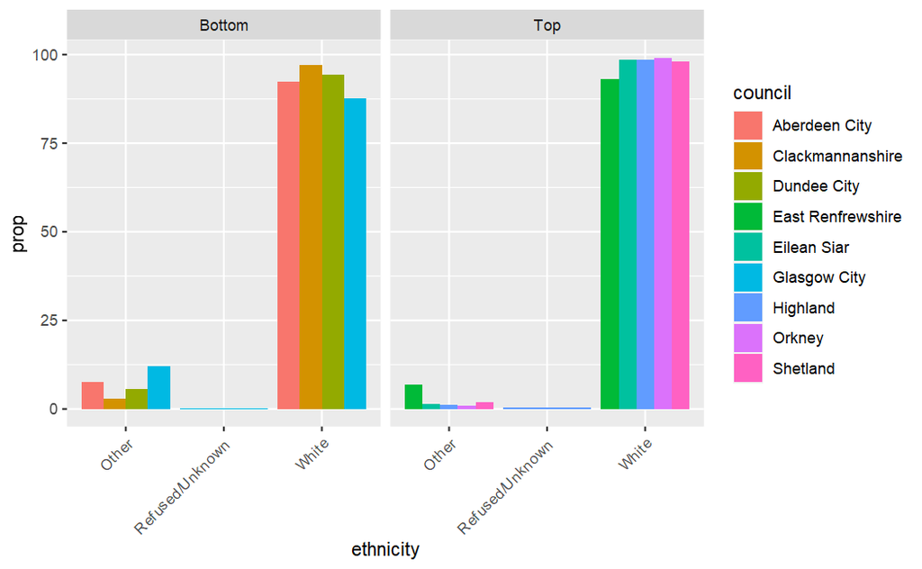

```r
plot_demographic_dist(ethnicity)
```

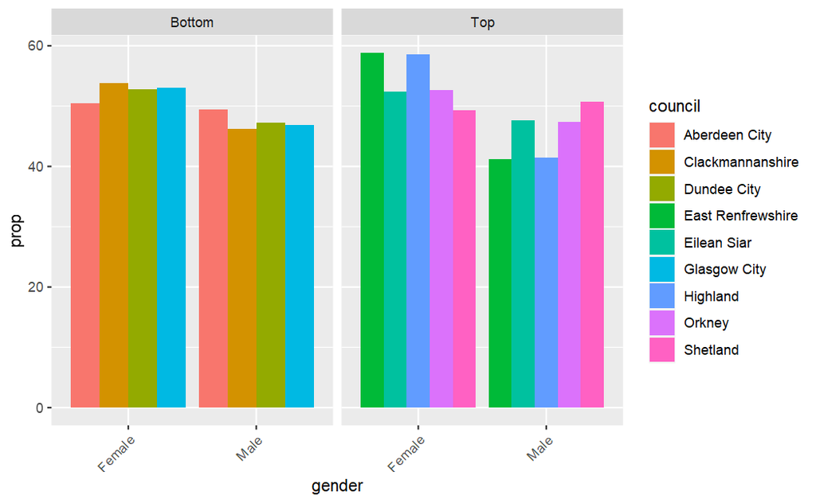

```r
plot_demographic_dist(gender)
```

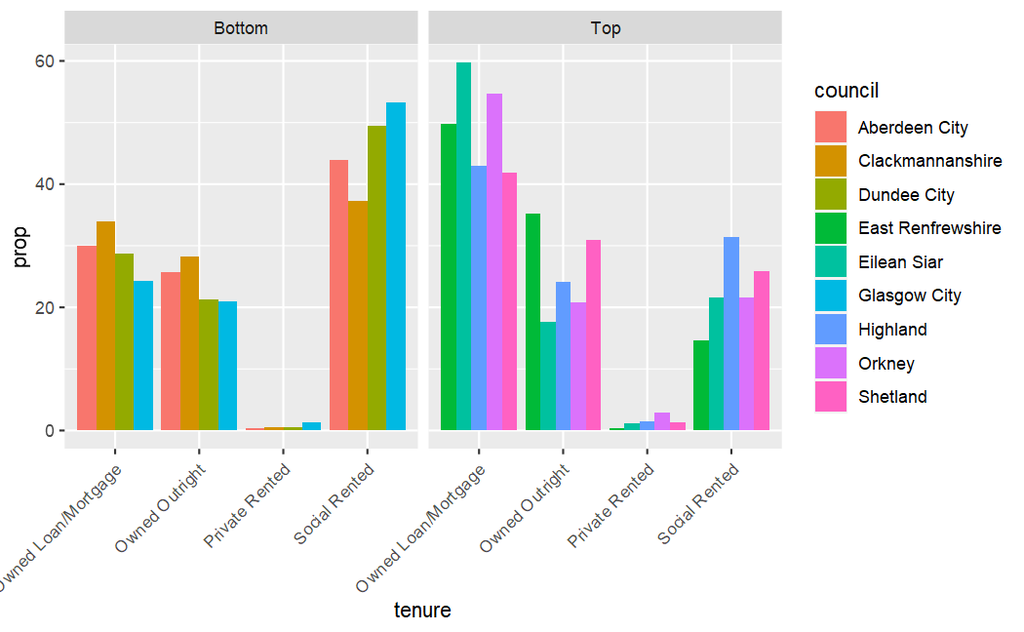

```r
plot_demographic_dist(tenure)
```

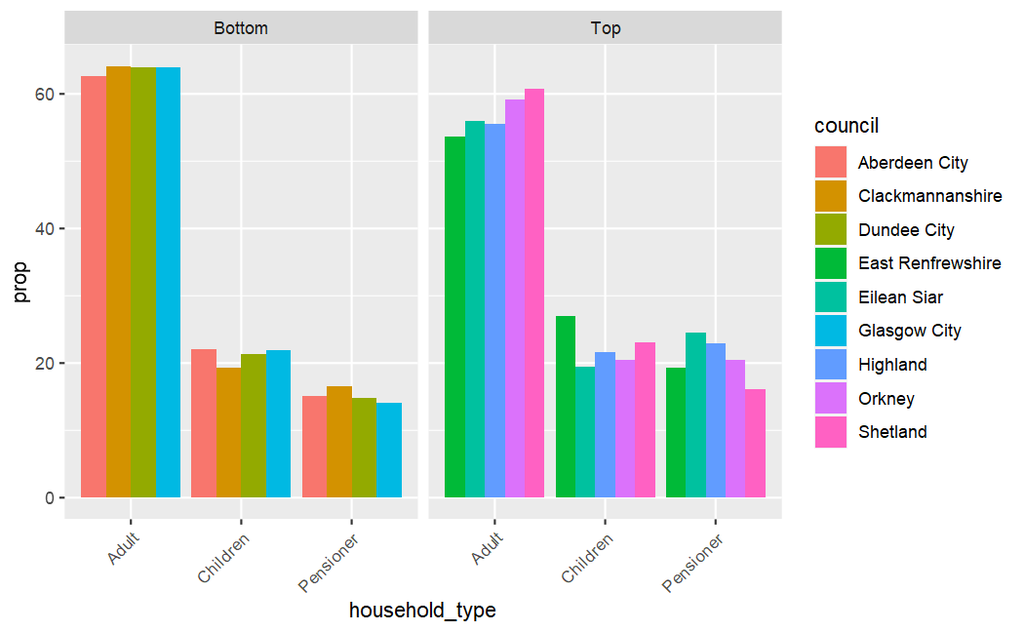

```r
plot_demographic_dist(household_type)
```

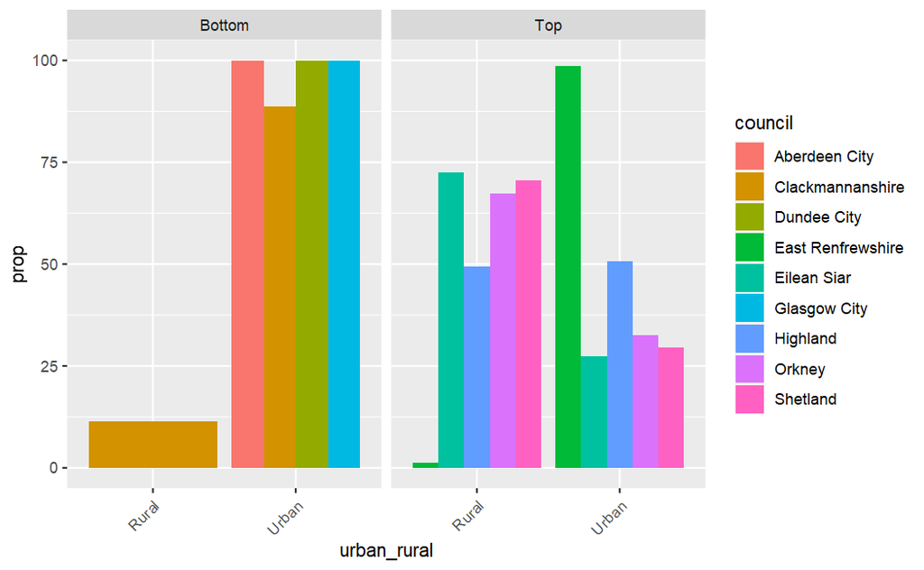

```r
plot_demographic_dist(urban_rural)
```

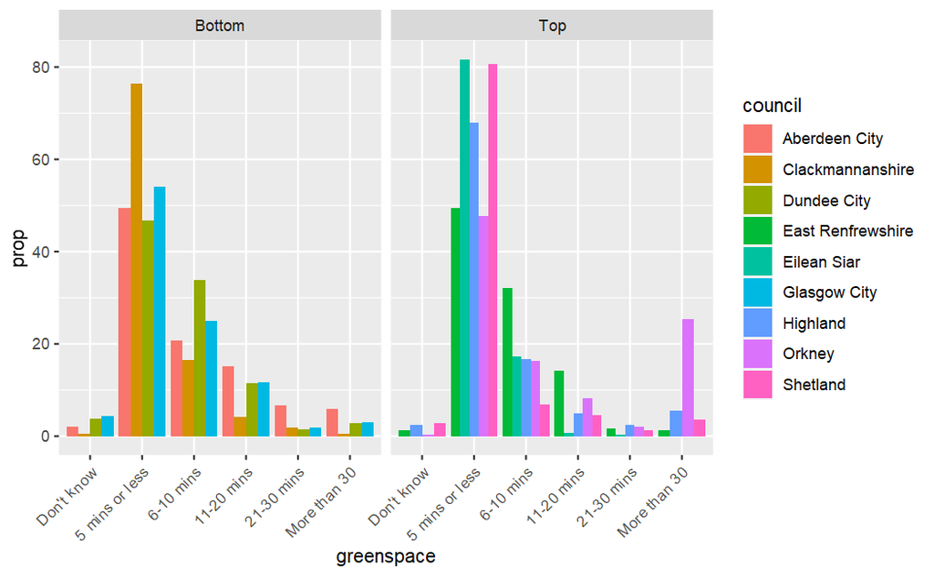

```r
plot_demographic_dist(greenspace)
```

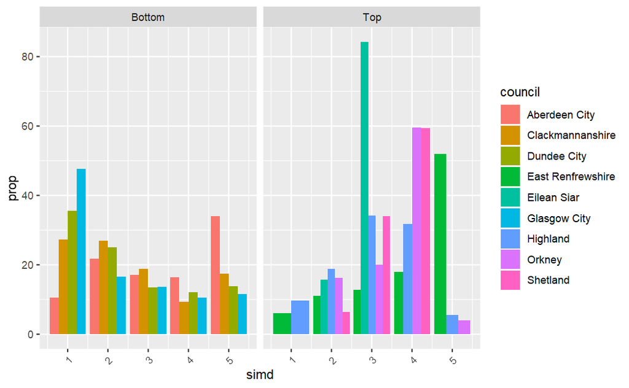

```r
plot_demographic_dist(simd)
```

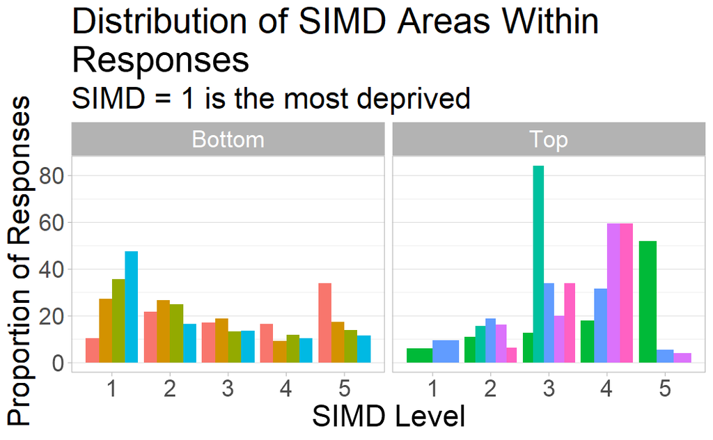

```r
data_clean %>%
  filter(council %in% c("Eilean Siar", "Orkney", "Shetland", "East Renfrewshire",
                        "Highland", "Dundee City", "Aberdeen City", "Glasgow City",
                        "West Dunbartonshire", "Clackmannanshire")) %>%
  mutate(top_bottom = case_when(
    council %in% c("Eilean Siar", "Orkney", "Shetland",
                   "East Renfrewshire", "Highland") ~ "Top",
    .default = "Bottom"
  )) %>%
  group_by(top_bottom, council, simd) %>%
  summarise(total = n()) %>%
  mutate(prop = (prop.table(total))*100) %>%
  ggplot(aes(simd, prop, fill = council)) +
  geom_col(position = "dodge", show.legend = FALSE) +
  facet_wrap(~top_bottom) +
  labs(
    title = "Distribution of SIMD Areas Within\nResponses",
    subtitle = "SIMD = 1 is the most deprived",
    fill = "Council Area",
    y = "Proportion of Responses",
    x = "SIMD Level"
  ) +
  theme_light() +
  theme(panel.grid.major.x = element_blank(),
        panel.grid.minor.x = element_blank(),
        text = element_text(size = 22))
ggsave("graphs_and_images/simd_dist.png")
```

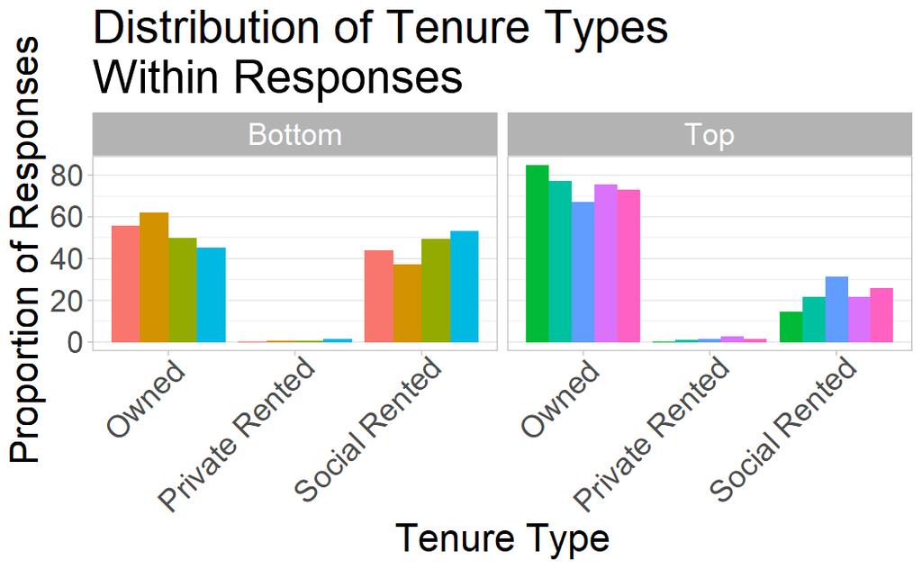

```r
data_clean %>%
  filter(council %in% c("Eilean Siar", "Orkney", "Shetland", "East Renfrewshire",
                        "Highland", "Dundee City", "Aberdeen City", "Glasgow City",
                        "West Dunbartonshire", "Clackmannanshire")) %>%
  mutate(top_bottom = case_when(
    council %in% c("Eilean Siar", "Orkney", "Shetland",
                   "East Renfrewshire", "Highland") ~ "Top",
    .default = "Bottom"
  ),
  tenure = case_when(
    str_detect(tenure, "Owned") ~ "Owned",
    .default = tenure
  )) %>%
  group_by(top_bottom, council, tenure) %>%
  summarise(total = n()) %>%
  mutate(prop = (prop.table(total))*100) %>%
  ggplot(aes(tenure, prop, fill = council)) +
  geom_col(position = "dodge", show.legend = FALSE) +
  facet_wrap(~top_bottom) +
  theme_light() +
  theme(panel.grid.major.x = element_blank(),
        panel.grid.minor.x = element_blank(),
        axis.text.x = element_text(angle = 45, hjust = 1),
        text = element_text(size = 22)) +
  labs(
    title = "Distribution of Tenure Types\nWithin Responses",
    fill = "Council Area",
    y = "Proportion of Responses",
    x = "Tenure Type"
  )
ggsave("graphs_and_images/tenure_dist.png")
```

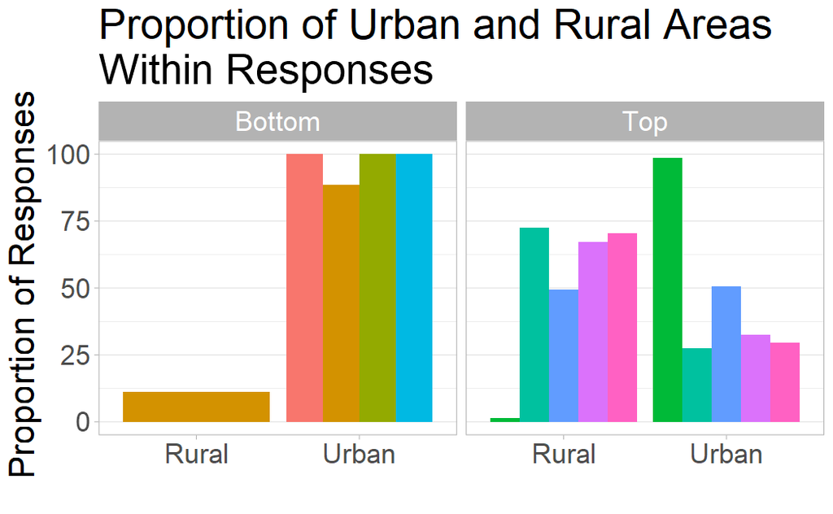

```r
data_clean %>%
  filter(council %in% c("Eilean Siar", "Orkney", "Shetland", "East Renfrewshire",
                        "Highland", "Dundee City", "Aberdeen City", "Glasgow City",
                        "West Dunbartonshire", "Clackmannanshire")) %>%
  mutate(top_bottom = case_when(
    council %in% c("Eilean Siar", "Orkney", "Shetland",
                   "East Renfrewshire", "Highland") ~ "Top",
    .default = "Bottom"
  )) %>%
  group_by(top_bottom, council, urban_rural) %>%
  summarise(total = n()) %>%
  mutate(prop = (prop.table(total))*100) %>%
  ggplot(aes(urban_rural, prop, fill = council)) +
  geom_col(position = "dodge", show.legend = FALSE) +
  facet_wrap(~top_bottom) +
  labs(
    title = "Proportion of Urban and Rural Areas\nWithin Responses",
    fill = "Council Area",
    y = "Proportion of Responses",
    x = ""
  ) +
  theme_light() +
  theme(panel.grid.major.x = element_blank(),
        panel.grid.minor.x = element_blank(),
        text = element_text(size = 22))
ggsave("graphs_and_images/urban_dist.png")
```

[figure not shown]

```r
plot_demographic_dist(household_type)
```

[figure not shown]

```r
plot_demographic_dist(urban_rural)
```

[figure not shown]

```r
plot_demographic_dist(greenspace)
```

[output not shown]

[output cut: 990 more lines]

```r
scotland_ethnicity <- data_clean %>%
  group_by(ethnicity) %>%
  summarise(n(),
            prop = (n()/nrow(data_clean))*100)
```

```r
scotland_simd <- data_clean %>%
  group_by(simd) %>%
  summarise(n(),
            prop = (n()/nrow(data_clean))*100)
```

```r
scotland_urban <- data_clean %>%
  group_by(urban_rural) %>%
  summarise(n(),
            prop = (n()/nrow(data_clean))*100)
```

```r
scotland_household <- data_clean %>%
  group_by(household_type) %>%
  summarise(n(),
            prop = (n()/nrow(data_clean))*100)
```

```r
scotland_tenure <- data_clean %>%
  group_by(tenure) %>%
  summarise(n(),
            prop = (n()/nrow(data_clean))*100)
```

```r
scotland_greenspace <- data_clean %>%
  group_by(greenspace) %>%
  summarise(n(),
            prop = (n()/nrow(data_clean))*100)
```

[figure not shown]

```r
data_clean %>%
  group_by(council, simd) %>%
  summarise(prop = (n()/nrow(data_clean))*100) %>%
  ggplot(aes(simd, prop)) +
  geom_col() +
  facet_wrap(~council)
```

## Orkney

[output not shown]

[output cut: 990 more lines]

```r
scotland_simd <- data_clean %>%
  group_by(simd) %>%
  summarise(n(),
            prop = (n()/nrow(data_clean))*100)
```

```r
scotland_urban <- data_clean %>%
  group_by(urban_rural) %>%
  summarise(n(),
            prop = (n()/nrow(data_clean))*100)
```

```r
scotland_household <- data_clean %>%
  group_by(household_type) %>%
  summarise(n(),
            prop = (n()/nrow(data_clean))*100)
```

```r
scotland_tenure <- data_clean %>%
  group_by(tenure) %>%
  summarise(n(),
            prop = (n()/nrow(data_clean))*100)
```

```r
scotland_greenspace <- data_clean %>%
  group_by(greenspace) %>%
  summarise(n(),
            prop = (n()/nrow(data_clean))*100)
```

```r
full_data_2019 %>%
  filter(rand_ok == 1) %>%
  select(dyear, council, randage, randgender, randecon,
         tenure_harm, hhtype_new, rb1:asb1i) %>%
  mutate(council = case_when(
    council == "T" ~ "Moray",
    council == "5" ~ "West Lothian",
    council == "Y" ~ "Renfrewshire",
    council == "C" ~ "Angus",
    council == "R" ~ "Inverclyde",
    council == "U" ~ "North Ayrshire",
    council == "X" ~ "Perth and Kinross",
    council == "6" ~ "Eilean Siar",
    council == "B" ~ "Aberdeenshire",
    council == "D" ~ "Argyll and Bute",
    council == "E" ~ "Scottish Borders",
    council == "H" ~ "Dundee City",
    council == "1" ~ "South Ayrshire",
    council == "2" ~ "South Lanarkshire",
    council == "F" ~ "Clackmannanshire",
    council == "G" ~ "Dumfries and Galloway",
    council == "Q" ~ "Highland",
    council == "3" ~ "Stirling",
    council == "A" ~ "Aberdeen City",
    council == "4" ~ "West Dumbartonshire",
    council == "L" ~ "East Renfrewshire",
    council == "N" ~ "Falkirk",
    council == "K" ~ "East Lothian",
    council == "O" ~ "Fife",
    council == "J" ~ "East Dumbartonshire",
    council == "W" ~ "Orkney",
    council == "P" ~ "Glasgow City",
    council == "Z" ~ "Shetland",
    council == "V" ~ "North Lanarkshire",
    council == "I" ~ "East Ayrshire",
    council == "S" ~ "Midlothian",
    council == "M" ~ "Edinburgh City"
  ))
```